# Data manipulation with R

# Data display

The first thing to do when having data at hand data is exploring it. We use the dataset `mtcars`, one of the several pre-loaded datasets in R, as an introductory example.[^9]

First we must make sure the import process was successful (check the number of rows and columns, make sure the numeric fields are not imported as strings, etc.).

```r
class(mtcars)
```

```
## [1] "data.frame"
```

```r
str(mtcars)
```

```
## 'data.frame':    32 obs. of  11 variables:
##  $ mpg : num  21 21 22.8 21.4 18.7 18.1 14.3 24.4 22.8 19.2 ...
##  $ cyl : num  6 6 4 6 8 6 8 4 4 6 ...
##  $ disp: num  160 160 108 258 360 ...
##  $ hp  : num  110 110 93 110 175 105 245 62 95 123 ...
##  $ drat: num  3.9 3.9 3.85 3.08 3.15 2.76 3.21 3.69 3.92 3.92 ...
##  $ wt  : num  2.62 2.88 2.32 3.21 3.44 ...
##  $ qsec: num  16.5 17 18.6 19.4 17 ...
##  $ vs  : num  0 0 1 1 0 1 0 1 1 1 ...
##  $ am  : num  1 1 1 0 0 0 0 0 0 0 ...
##  $ gear: num  4 4 4 3 3 3 3 4 4 4 ...
##  $ carb: num  4 4 1 1 2 1 4 2 2 4 ...
```

```r
dim(mtcars)
```

```
## [1] 32 11
```

```r
names(mtcars)
```

```
##  [1] "mpg"  "cyl"  "disp" "hp"   "drat" "wt"   "qsec" "vs"   "am"   "gear"
## [11] "carb"
```

```r
summary(mtcars)
```

```
##       mpg             cyl             disp             hp
##  Min.   :10.40   Min.   :4.000   Min.   : 71.1   Min.   : 52.0
##  1st Qu.:15.43   1st Qu.:4.000   1st Qu.:120.8   1st Qu.: 96.5
##  Median :19.20   Median :6.000   Median :196.3   Median :123.0
##  Mean   :20.09   Mean   :6.188   Mean   :230.7   Mean   :146.7
##  3rd Qu.:22.80   3rd Qu.:8.000   3rd Qu.:326.0   3rd Qu.:180.0
##  Max.   :33.90   Max.   :8.000   Max.   :472.0   Max.   :335.0
##       drat             wt             qsec             vs
##  Min.   :2.760   Min.   :1.513   Min.   :14.50   Min.   :0.0000
##  1st Qu.:3.080   1st Qu.:2.581   1st Qu.:16.89   1st Qu.:0.0000
##  Median :3.695   Median :3.325   Median :17.71   Median :0.0000
##  Mean   :3.597   Mean   :3.217   Mean   :17.85   Mean   :0.4375
##  3rd Qu.:3.920   3rd Qu.:3.610   3rd Qu.:18.90   3rd Qu.:1.0000
##  Max.   :4.930   Max.   :5.424   Max.   :22.90   Max.   :1.0000
##        am              gear            carb
##  Min.   :0.0000   Min.   :3.000   Min.   :1.000
##  1st Qu.:0.0000   1st Qu.:3.000   1st Qu.:2.000
##  Median :0.0000   Median :4.000   Median :2.000
##  Mean   :0.4062   Mean   :3.688   Mean   :2.812
##  3rd Qu.:1.0000   3rd Qu.:4.000   3rd Qu.:4.000
##  Max.   :1.0000   Max.   :5.000   Max.   :8.000
```

```r
sapply(mtcars, class)
```

```
##       mpg       cyl      disp        hp      drat        wt      qsec        vs
## "numeric" "numeric" "numeric" "numeric" "numeric" "numeric" "numeric" "numeric"
##        am      gear      carb
## "numeric" "numeric" "numeric"
```

Then we can inspect visually our table. Since most of our tables have many more rows than our screens can show we start by looking at the top and bottom rows.

```r
head(mtcars)
```

```
##                    mpg cyl disp  hp drat    wt  qsec vs am gear carb
## Mazda RX4         21.0   6  160 110 3.90 2.620 16.46  0  1    4    4
## Mazda RX4 Wag     21.0   6  160 110 3.90 2.875 17.02  0  1    4    4
## Datsun 710        22.8   4  108  93 3.85 2.320 18.61  1  1    4    1
## Hornet 4 Drive    21.4   6  258 110 3.08 3.215 19.44  1  0    3    1
## Hornet Sportabout 18.7   8  360 175 3.15 3.440 17.02  0  0    3    2
## Valiant           18.1   6  225 105 2.76 3.460 20.22  1  0    3    1
```

```r
tail(mtcars)
```

```
##                 mpg cyl  disp  hp drat    wt qsec vs am gear carb
## Porsche 914-2  26.0   4 120.3  91 4.43 2.140 16.7  0  1    5    2
## Lotus Europa   30.4   4  95.1 113 3.77 1.513 16.9  1  1    5    2
## Ford Pantera L 15.8   8 351.0 264 4.22 3.170 14.5  0  1    5    4
## Ferrari Dino   19.7   6 145.0 175 3.62 2.770 15.5  0  1    5    6
## Maserati Bora  15.0   8 301.0 335 3.54 3.570 14.6  0  1    5    8
## Volvo 142E     21.4   4 121.0 109 4.11 2.780 18.6  1  1    4    2
```

```r
# you can specify the number of rows
head(mtcars, 10)
```

```
##                    mpg cyl  disp  hp drat    wt  qsec vs am gear carb
## Mazda RX4         21.0   6 160.0 110 3.90 2.620 16.46  0  1    4    4
## Mazda RX4 Wag     21.0   6 160.0 110 3.90 2.875 17.02  0  1    4    4
## Datsun 710        22.8   4 108.0  93 3.85 2.320 18.61  1  1    4    1
## Hornet 4 Drive    21.4   6 258.0 110 3.08 3.215 19.44  1  0    3    1
## Hornet Sportabout 18.7   8 360.0 175 3.15 3.440 17.02  0  0    3    2
## Valiant           18.1   6 225.0 105 2.76 3.460 20.22  1  0    3    1
## Duster 360        14.3   8 360.0 245 3.21 3.570 15.84  0  0    3    4
## Merc 240D         24.4   4 146.7  62 3.69 3.190 20.00  1  0    4    2
## Merc 230          22.8   4 140.8  95 3.92 3.150 22.90  1  0    4    2
## Merc 280          19.2   6 167.6 123 3.92 3.440 18.30  1  0    4    4
```

After this visual inspection we can describe individual columns, summary tables for categorical data, histograms and descriptive statistics for numeric data, etc.

# Basic graphics

Visualizing results for your analysis is critical for its success - conveying the right message). R is extraordinary powerful at graphing data, allowing a great degree of personalization and having several state-of-the-art packages.

We will start with the basics[^10], and later on we will use `ggplot2` - the package for advanced plotting in R.

**Stripcharts** are one-dimensional scatter plots and provide a (somewhat simplistic) first look at univariate series. Note the optional parameter `xlab` for setting the X-axis title.

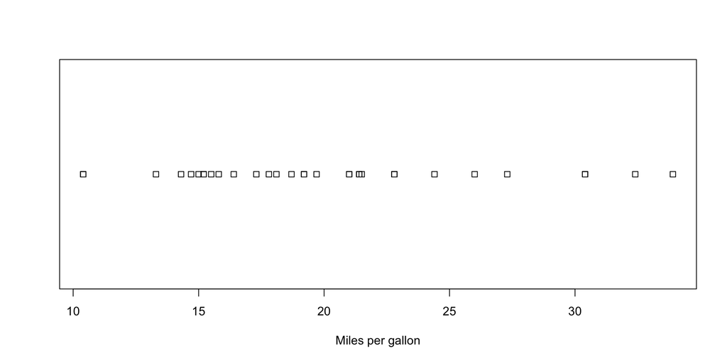

Stripchart: first look at mpg.

```r
stripchart(mtcars$mpg, xlab = "Miles per gallon")
```

A **histogram** cuts series in discrete bins, while a continuous distribution varies smoothly along the series. Histogram of mileage in the `mtcars` dataset.

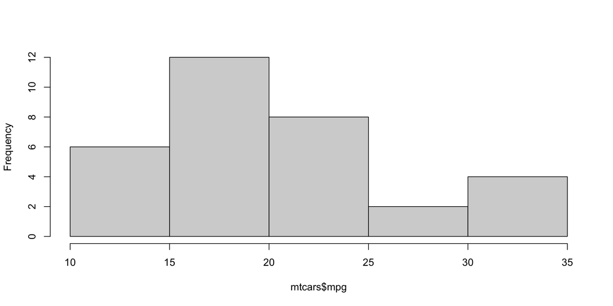

Histogram of mileage.

```r
hist(mtcars$mpg, main = "")
```

The default number of bins may be misleading, we can set more bins (maybe after some trial and error). Using the optional parameter `col` (setting the fill color for the histogram bins) helps focusing on the important message - the distribution.

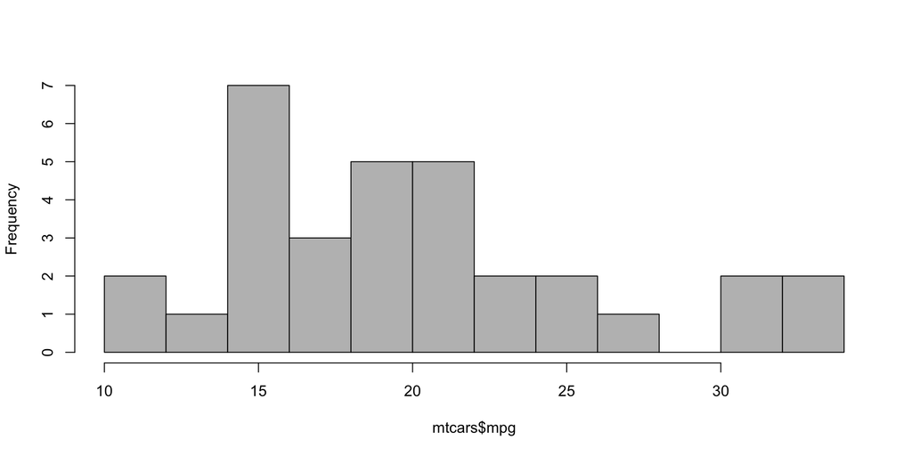

Smoother histogram of mpg.

```r
hist(mtcars$mpg, col = "gray", breaks = 10, main = "")
```

The **kernel density** estimate is a hypothetical continuous distribution generating a univariate series and provides a smooth approximation for the actual distribution. Kernel density estimates are closely related to histograms, but can be endowed with properties such as smoothness or continuity by using a suitable kernel.

Note we must first compute the estimated density with the `density` function.

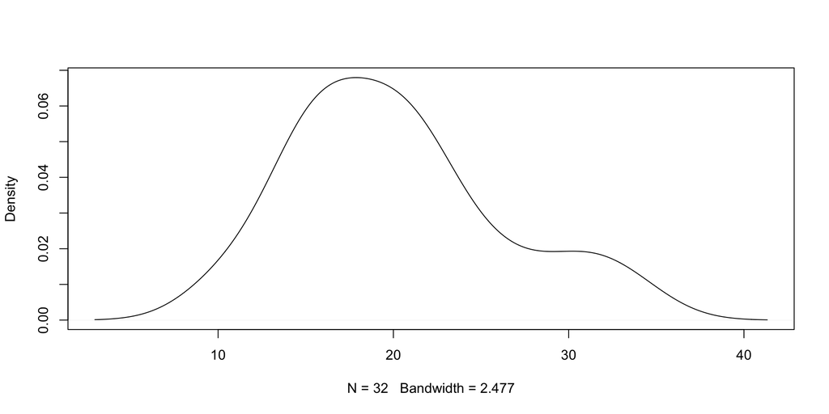

Density estimate of mileage.

```r
# Compute the density data
d <- density(mtcars$mpg)

# Graph the results
plot(d, main = "")
```

**Boxplots** summarize univariate series in a single plot (including the range of the variable, its quartiles, and its outliers).[^11] In future lectures we will dig deeper on summarizing distributions. Here we will only plot the classical boxplot, grouping by the number of cylinders.

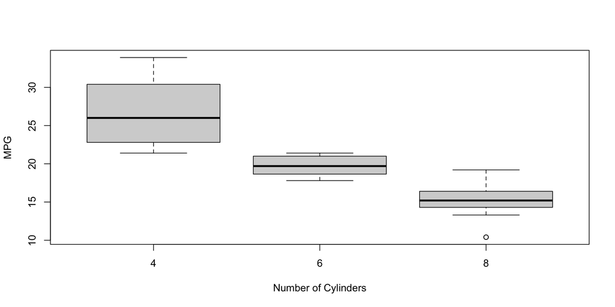

Example of boxplot summary, car milage data

```r
boxplot(mpg ~ cyl, data = mtcars, ylab = "MPG",
        xlab = "Number of Cylinders")
```

**Scatterplots** display values for two variables for a set of data, and are essential when looking for relationships between them (e.g. linear correlation). In R the simplest way to plot them is the `plot` function, where we can also add a regression line.

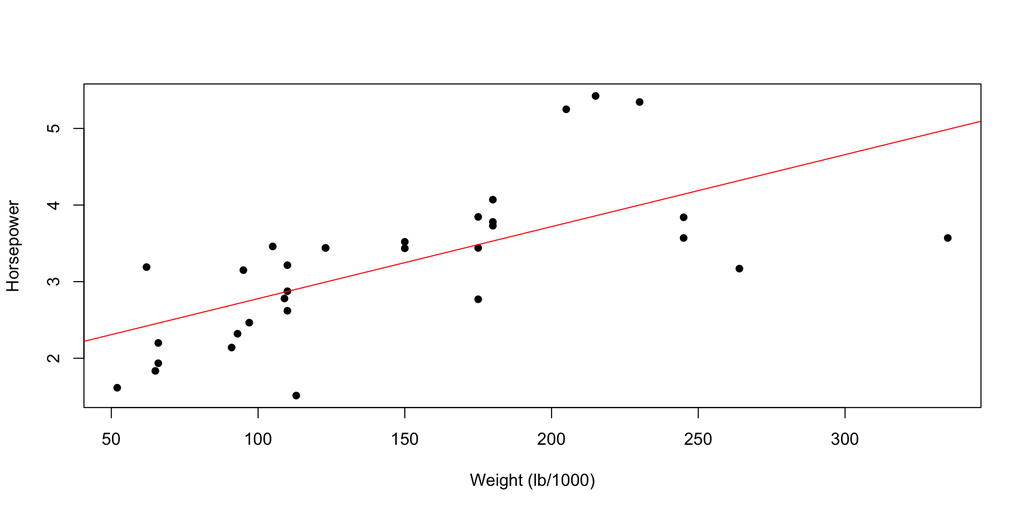

Hp vs weight: scatterplot and linear regression

```r
# Scatterplot
plot(x = mtcars$hp, y = mtcars$wt, ylab = "Horsepower",
     xlab = "Weight (lb/1000)", pch = 16)

# Linear regression line
abline(lm(mtcars$wt ~ mtcars$hp), col = "red")
```

**Practice** describing BCN census data. Use the Demographic data of census sections in Barcelona we imported earlier and …

1. produce stripcharts, histograms and kernel density estimates of a variable of your choice. Be creative: define a new variable combining existing ones, combine colors, explore optional parameters of the functions.
2. scatterplot two variables and add a linear regression line. Try adding a loess regression curve. Choose appropriate point characters and point dimensions (with lots of data points maybe blank-filled smaller dots are most convenient).
3. challenging bit: use the layout function to display all the univariate plots in a single matrix of plots.

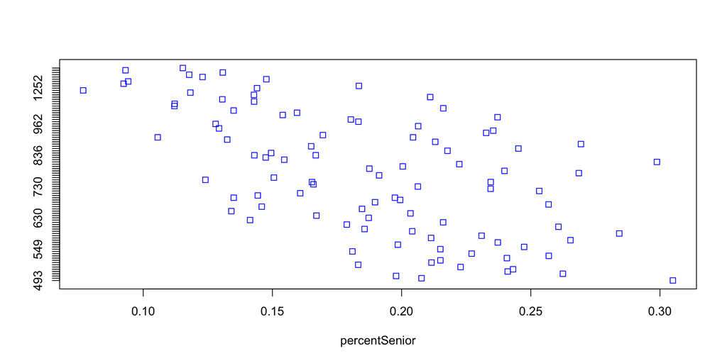

```r
#1
censusBCN$women2men_ratio <- censusBCN$Women / censusBCN$Men
stripchart(percentSenior ~ Men, data=censusBCN[1:100,],col='blue')
```

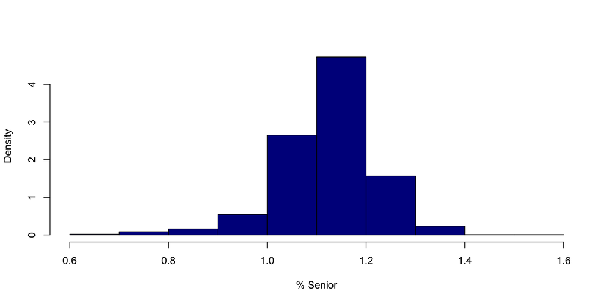

```r
hist(censusBCN$women2men_ratio, col='darkblue',main=NULL,xlab='% Senior',freq=F)
```

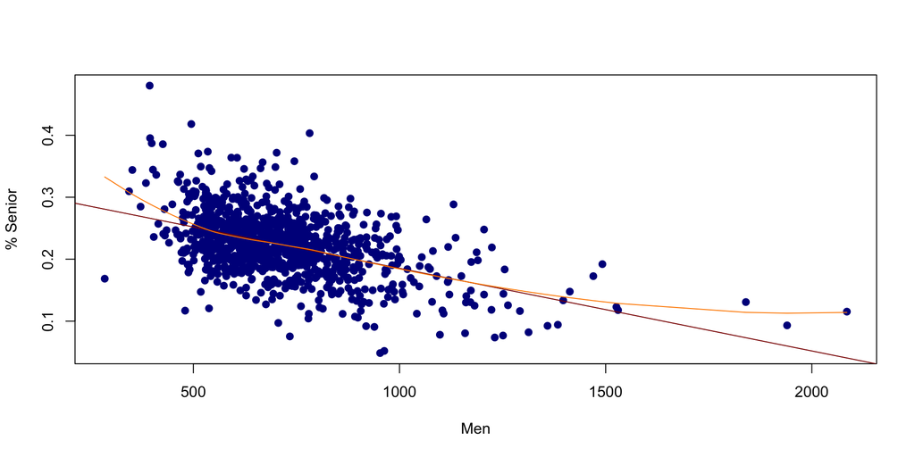

```r
# 2
plot(censusBCN$percentSenior ~censusBCN$Men,
     pch=19,
     cex=1,
     col='darkblue',
     xlab='Men',
     ylab='% Senior')
abline(lm(percentSenior~Men,data=censusBCN),col='darkred')
# add local polynomial regression
x <- censusBCN$Men[order(censusBCN$Men)]
y <- loess(percentSenior~Men,data=censusBCN)$fitted[order(censusBCN$Men)]
lines(x=x, y=y, col='darkorange',pch=19,cex=1)
```

## A full example of a customized plot

Plotting data in R is always easy, but obtaining the format you need almost never is. Some packages will make your life easier, but you need to learn the basics of plot personalization. This is another powerful R feature.

Say we want to plot the miles per gallon of the `mtcars` data set. It is pretty straightforward.

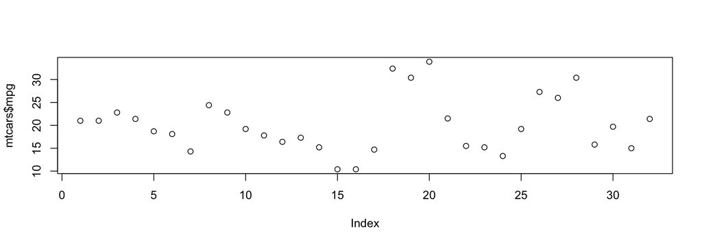

A first attempt plotting miles per gallon.

```r
plot(mtcars$mpg)
```

But you will agree it is also disappointing - bad axis titles, no main title, no identification of each car etc. But these flaws are also strengths. Plots are objects as any other and all the elements can be personalized and coded. This way, they can be reproduced when data change or if you share your code.

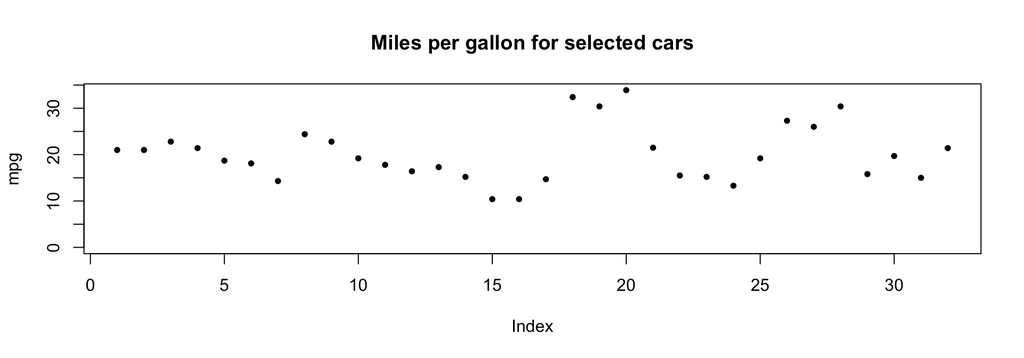

Our second attempt.

```r
plot(mtcars$mpg,
     main = "Miles per gallon for selected cars",
     ylab = "mpg",
     pch = 16,
     cex = 0.8,
     ylim = c(0,max(mtcars$mpg))
    )
```

Now we have fixed some of these issues: `main` and `ylab` improve titles, `pch` and `cex` improve formats, `ylim` lets us set the axis limits. But the X axis remains without the proper car labels. Let us fix that too.

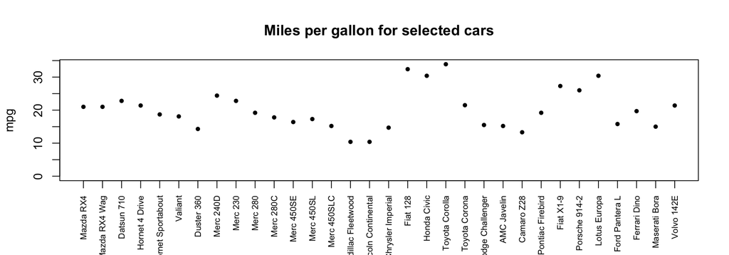

Now the X axis is informative.

```r
plot(mtcars$mpg,
     main = "Miles per gallon for selected cars",
     ylab = "mpg",
     pch = 16,
     cex = 0.8,
     ylim = c(0, max(mtcars$mpg)),
     xaxt = "n",
     xlab = "")

axis(side = 1,
     at = seq_along(mtcars$mpg),
     labels = rownames(mtcars),
     las = 2,
     cex.axis = 0.7)
```

With the axis function we can control the position and content of the axes (here the X axis, or side=1).

Maybe adding vertical gridlines will help identifying each car, and coloring according to the cylinders may be informative.

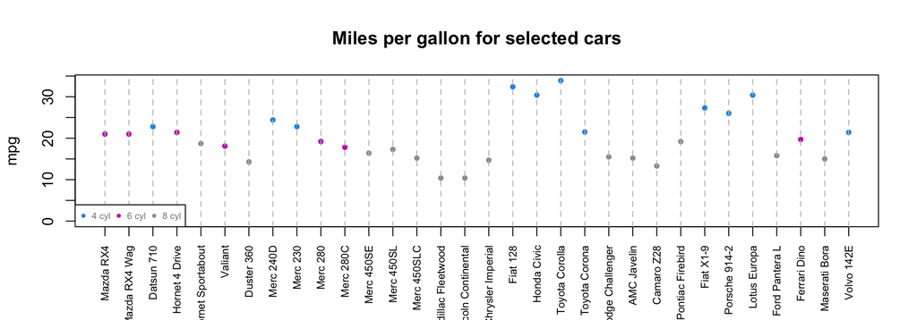

Finally a plot both informative and well formatted.

```r
plot(mtcars$mpg,
     main = "Miles per gallon for selected cars",
     ylab = "mpg",
     pch = 16,
     cex = 0.8,
     ylim = c(0, max(mtcars$mpg)),
     xaxt = "n",
     xlab = "",
     col = mtcars$cyl)

axis(side = 1,
     at = seq_along(mtcars$mpg),
     labels = rownames(mtcars),
     las = 2,
     cex.axis = 0.7)

abline(v = seq_along(mtcars$mpg),
       col = "gray",
       lty = 2)

legend(x = "bottomleft", ncol = 3, cex = 0.6,
       bg = "white",
       legend = c("4 cyl", "6 cyl", "8 cyl"),
       text.col = "azure4",
       col = c(4, 6, 8), pch = 16)
```

Changing fonts is a bit more tricky. Moreover, R by default uses Helvetica font in figures and these fonts are not necessarily available everywhere as it is a commercial font. Hence, some pdf readers might not render correctly the figures. See `extrafont` package for some extra options with fonts.

## Saving plots

By default, a plot in R opens a device in your desktop (or within RStudio). But usually you will need to save it as a high-quality image. R allows different output formats for graphics (pdf, jpg, png). Here we will set an example of pdf output.

```r
## Open the device
pdf("mileage.pdf", width = 10, height = 2.5)

## Add the plot
plot(mtcars$mpg)
abline(h = mean(mtcars$mpg),
       col = "lightgray",
       lty = 2)

## Close the device
dev.off()
```

Note that no directory path is specified. By default, the file will be saved at the current working directory, optionally you can set a different output directory.

# Basic text manipulation

In almost every analysis you need to perform operations on dates and text strings. Here we will take a look at the essential operations on these types of data.

Handling strings in R can sometimes be painful.[^12] Several packages exist that ease this pain. Here we look only at R base functions.

The `paste` function is perhaps the most used in R when handling strings. It essentially concatenates strings, but in a generalized way (e.g. you can choose the character separating strings, or it converts non-string objects to characters). By default, it concatenates strings separating them with a blank space.

```r
paste("Barcelona", "GSE")
```

```
## [1] "Barcelona GSE"
```

The sep parameter sets a different separator. The `paste0` function is a convenient alternative when you don’t want any form of separation, so it is as if you set `sep = ""`.

```r
paste("Barcelona", "GSE", sep = "-")
```

```
## [1] "Barcelona-GSE"
```

```r
paste0("Barcelona", "GSE")
```

```
## [1] "BarcelonaGSE"
```

Numeric variables are coerced to strings.

```r
paste("The Life of", pi)
```

```
## [1] "The Life of 3.14159265358979"
```

You can also operate with vectors.

```r
paste("Class of 201", 4:7, sep = "")
```

```
## [1] "Class of 2014" "Class of 2015" "Class of 2016" "Class of 2017"
```

Count number of characters: `nchar` function works both with a single string or with a vector.

```r
nchar(c("How", "many", "characters?"))
```

```
## [1]  3  4 11
```

```r
nchar("How many characters?")
```

```
## [1] 20
```

Convert to lower/upper case with `tolower` and `toupper` functions. Again, they also work on vectors.

```r
tolower("Barcelona GSE")
```

```
## [1] "barcelona gse"
```

```r
toupper(c("Barcelona", "GSE"))
```

```
## [1] "BARCELONA" "GSE"
```

Obtain and replace substrings with `substr` function.

```r
substr("Barcelona GSE", start = 11, stop = 13)
```

```
## [1] "GSE"
```

```r
days <- c("Mond", "Tues", "Wedn")
substr(days, 4, 4) <- "."
days
```

```
## [1] "Mon." "Tue." "Wed."
```

Character translation with `chartr`.

```r
chartr(old = "4", new = "a", "B4rcelon4 GSE")
```

```
## [1] "Barcelona GSE"
```

```r
chartr(old = "410", new = "aio",
       "B4rcel0n4 Gr4du4te Sch00l of Ec0n0m1cs")
```

```
## [1] "Barcelona Graduate School of Economics"
```

Uniquely abbreviate strings with `abbreviate`.

```r
abbreviate(c("Asset Pricing", "Corporate Finance",
             "Econometrics"), minlength = 5)
```

```
##     Asset Pricing Corporate Finance      Econometrics
##           "AsstP"           "CrprF"           "Ecnmt"
```

**Practice** character to numeric when importing. The Aging Population data imported earlier has some numerical columns stored as character. Use basic string manipulations to convert them back into numerical.[^13]

```r
agingPopulation$Total.Population <-
  as.numeric(gsub(',','',agingPopulation$Total.Population))
agingPopulation$PercentSeniors <-
  as.numeric(gsub('%','',agingPopulation$PercentSeniors))
```

# Dates and times in R

Dates are represented as the number of days since 1970-01-01, with negative values for earlier dates. But R outputs them with the familiar formats (e.g. MMDDYYY). Converting to/from dates and operating with them requires some familiarity with the main R date formats and functions.[^14] There are packages like `lubridate` that facilitate handling of dates and time.

**System date and time** are useful for many purposes (e.g. computing execution times, saving files with dynamical names).

```r
# System date with default format
Sys.time()
```

```
## [1] "2020-09-10 13:16:26 CEST"
```

```r
# Time with HH:MM:SS format
format(Sys.time(), "%H:%M:%S")
```

```
## [1] "13:16:26"
```

```r
# Date with YYYYMMDD format
format(Sys.time(), "%Y-%m-%d")
```

```
## [1] "2020-09-10"
```

```r
# using system time for measuring difference
x <- Sys.time()
y <- Sys.time()
y - x
```

```
## Time difference of 0.001026869 secs
```

```r
# there is a specific function for that
system.time(
    for(i in 1:100) mad(runif(1000))
)
```

```
##    user  system elapsed
##   0.038   0.003   0.043
```

Converting strings to date/time objects is the name of the game when importing data files. Being familiar with date conversion and formatting is also crucial when reporting results. Some examples.

```r
# Input date format
x <- as.Date("20140912", format = "%Y%m%d")
x
```

```
## [1] "2014-09-12"
```

```r
class(x)
```

```
## [1] "Date"
```

```r
typeof(x)
```

```
## [1] "double"
```

```r
# Input time and date
strptime("09/12/11 17.30.00", format = "%m/%d/%y %H.%M.%S")
```

```
## [1] "2011-09-12 17:30:00 CEST"
```

```r
# convert to string
as.character(Sys.time())
```

```
## [1] "2020-09-10 13:16:26"
```

**Extracting information from dates.**

```r
# Name of weekday
weekdays(Sys.time())
```

```
## [1] "Thursday"
```

```r
# Name of month
months(Sys.time())
```

```
## [1] "September"
```

```r
# Number of days since beginning of epoch
julian(Sys.time())
```

```
## Time difference of 18515.47 days
```

**Generating sequences of dates**

```r
seq(from = as.Date("2014-09-12"),
    to = as.Date("2014-09-14"),
    by = "day")
```

```
## [1] "2014-09-12" "2014-09-13" "2014-09-14"
```

```r
# All days between two dates
seq(from = as.Date("2014-09-12"),
    to = as.Date("2014-11-12"),
    by = "month")
```

```
## [1] "2014-09-12" "2014-10-12" "2014-11-12"
```

```r
# All months between two dates
seq(from = as.Date("2014-09-12"),
    to = as.Date("2014-09-16"),
    length.out = 3)
```

```
## [1] "2014-09-12" "2014-09-14" "2014-09-16"
```

```r
# Every other day between two dates
# Next 3 days
seq.Date(Sys.Date(), length = 3, by = "1 days")
```

```
## [1] "2020-09-10" "2020-09-11" "2020-09-12"
```

```r
# Next 3 months
seq.Date(Sys.Date(), length = 3, by = "1 months")
```

```
## [1] "2020-09-10" "2020-10-10" "2020-11-10"
```

Operations with dates.

```r
# Number of days since a given date
julian(Sys.time()) - julian(as.Date("2014-01-01"))
```

```
## Time difference of 2444.47 days
```

```r
# Adding days
as.Date("2014-09-12") + 30
```

```
## [1] "2014-10-12"
```

```r
# Adding months
seq.Date(Sys.Date(), length = 2, by = "3 months")[2]
```

```
## [1] "2020-12-10"
```

**Practice** proper formatting of dates in imported data. Create a new column in the BCN census data containing the day after the first column date. You must use the `as.Date` function.

# Time Series in R

Manipulating Time Series in R with what we have learnt so far is possible. However, the powerful package **eXtensible Time Series** `xts` can make our lives a lot easier. **xts** objects are simple, we just have to think of them as matrices of observations combined with an index of corresponding dates and times. To create an `xts` object, we just need to have a vector/matrix of observations and an index vector (date format) with the same length:

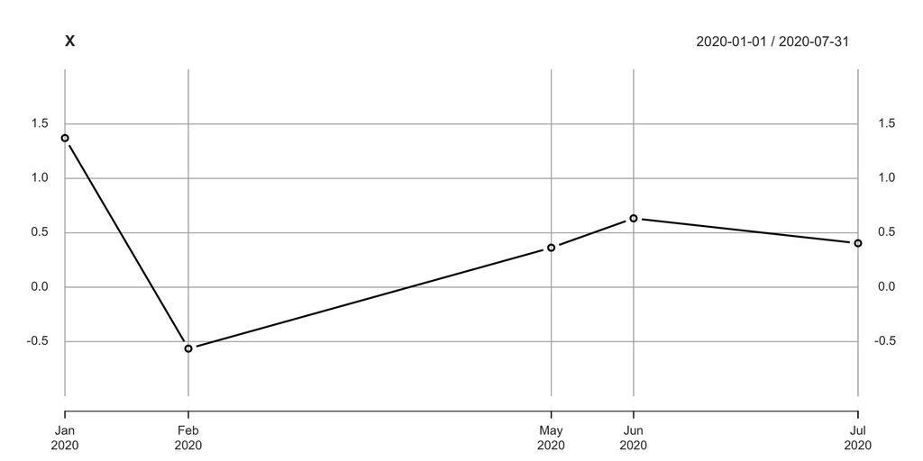

```r
# Load xts
if (!require(xts)) install.packages('xts') else library(xts)

# Generate normally distributed data
set.seed(42)
data <- data.frame(x=rnorm(5))

# Create dates as a Date class object (they can be irregularly spaced!)
dates <- as.Date(c("2020-01-01","2020-02-03",
                   "2020-05-10","2020-06-01",
                   "2020-07-31"))
# Create xts object
X <- xts(x = data, order.by = dates)

# Plot xts object
plot(X, type='b',ylim=c(-1,2))
```

```r
# Given an xts, it is also easy to extract the core data and the index
# in case you want to deal with them separately
class(coredata(X))
```

```
## [1] "matrix" "array"
```

```r
class(index(X))
```

```
## [1] "Date"
```

One major difference between xts and most other time series objects in R is the ability to use any one of various classes that are used to represent time. Whether POSIXct, Date, or some other class, xts will convert this into an internal form to make subsetting as natural to the user as possible.

```r
# Create dates
dates <- as.Date("2016-01-01") + 0:4

# Create ts_a with a Date object
ts_a <- xts(x = 1:5, order.by = dates)

# Create ts_b with POSIXct object
ts_b <- xts(x = 1:5, order.by = as.POSIXct(dates))

# Extract the rows of ts_a using the index of ts_b
ts_a[index(ts_a)]
```

```
##            [,1]
## 2016-01-01    1
## 2016-01-02    2
## 2016-01-03    3
## 2016-01-04    4
## 2016-01-05    5
```

```r
# Extract the rows of ts_b using the index of ts_a
ts_a[index(ts_b)]
```

```
##            [,1]
## 2016-01-01    1
## 2016-01-02    2
## 2016-01-03    3
## 2016-01-04    4
## 2016-01-05    5
```

## Importing data to xts

```r
tmp_file <- "http://s3.amazonaws.com/assets.datacamp.com/production/course_1127/datasets/tmp_file.csv"

# Create dat by reading tmp_file using read.csv
dat <- read.csv(tmp_file)

# Convert dat into xts
dat_xts <- xts(dat, order.by = as.Date(rownames(dat), "%m/%d/%Y"))

# Alternative: use read.zoo and convert to xts
dat_zoo <- as.xts(read.zoo(tmp_file, index.column=0, sep=',', format='%d/%m/%Y'))
```

## Exporting xts

If you are working exclusively in R, the most convenient way to export/import xts objects is by use of the `saveRDS()` and `readRDS()` functions. Of course, you could use `save()` but this is different since it saves the object with the name in the current environment, whereas `saveRDS()` just saves a representation of the object.

```r
f <- 'data/dat_zoo.rds'
saveRDS(object = dat_zoo, file = f)
class(readRDS(f))
```

```
## [1] "xts" "zoo"
```

But sometimes you find yourself needing to share results with others, often expecting data to be consumed by processes unaware of R and xts. In that case, one of the best ways to write an xts object from R is to use the zoo function `write.zoo`. In this brief exercise we will convert sunspots to xts and save it as sunspots_xts.

```r
# Get pre-loaded data and inspect the class
data(sunspots)
class(sunspots)
```

```
## [1] "ts"
```

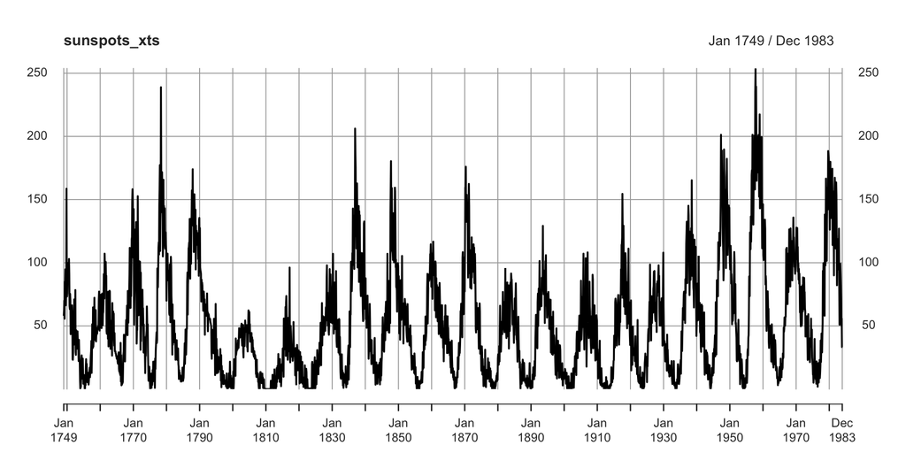

```r
# Convert sunspots to xts using as.xts().
sunspots_xts <- as.xts(sunspots)
plot(sunspots_xts)
```

```r
# Get the temporary file name
tmp <- tempfile()

# Write the xts object using zoo to tmp
write.zoo(sunspots_xts, sep = ",", file = tmp)

# Read the tmp file. FUN = as.yearmon converts strings such as Jan 1749 into a proper time class
sun <- read.zoo(tmp, sep = ",", FUN = as.yearmon)

# Convert sun into xts. Save this as sun_xts
sun_xts <- as.xts(sun)
```

## Extracting data

Extracting data is intuitive with xts objects. You can use the same indexing techniques as with matrices, and more. For instance, consider the following examples:

```r
# Extract first two observations
X[1:2]
```

```
##                     x
## 2020-01-01  1.3709584
## 2020-02-03 -0.5646982
```

```r
# Extract date '2020-06-01'
X['2020-06-01']
```

```
##                    x
## 2020-06-01 0.6328626
```

```r
# Extract year '2020'
X['2020']
```

```
##                     x
## 2020-01-01  1.3709584
## 2020-02-03 -0.5646982
## 2020-05-10  0.3631284
## 2020-06-01  0.6328626
## 2020-07-31  0.4042683
```

```r
# Extract only January and February data:
X['202001/202002']
```

```
##                     x
## 2020-01-01  1.3709584
## 2020-02-03 -0.5646982
```

```r
# Extract data from a given vector of dates
dates <- c('2020-05-10','2020-07-31')
X[dates]
```

```
##                    x
## 2020-05-10 0.3631284
## 2020-07-31 0.4042683
```

```r
# Extract first and last two months
first(X, "2 months")
```

```
##                     x
## 2020-01-01  1.3709584
## 2020-02-03 -0.5646982
```

```r
last(X, "2 months")
```

```
##                    x
## 2020-06-01 0.6328626
## 2020-07-31 0.4042683
```

Also it is possible to merge xts objects by date, combine rows/columns as with a data.frame structure, take differences in the data, lags, and many other convenient functions for time series analysis.

# Data Wrangling with dplyr

A package which is definitely worth exploring for data manipulation is `dplyr`. To illustrate, we use the `flights` dataset from the `nycflights13` package.

```r
head(flights,5)
```

```
## # A tibble: 5 x 19
##    year month   day dep_time sched_dep_time dep_delay arr_time sched_arr_time
##   <int> <int> <int>    <int>          <int>     <dbl>    <int>          <int>
## 1  2013     1     1      517            515         2      830            819
## 2  2013     1     1      533            529         4      850            830
## 3  2013     1     1      542            540         2      923            850
## 4  2013     1     1      544            545        -1     1004           1022
## 5  2013     1     1      554            600        -6      812            837
## # … with 11 more variables: arr_delay <dbl>, carrier <chr>, flight <int>,
## #   tailnum <chr>, origin <chr>, dest <chr>, air_time <dbl>, distance <dbl>,
## #   hour <dbl>, minute <dbl>, time_hour <dttm>
```

The `dplyr` package has a `filter()` function (note that when loading the package, the `filter()` function from the `stats` package is masked) which we can use as follows. Say we would like to get only the flights that happened in November or December, which arrived more than two hours late, but did not leave late. Then,

```r
filter(flights,
       month %in% c(11,12),
       dep_delay <= 0,
       arr_delay > 120)
```

```
## # A tibble: 1 x 19
##    year month   day dep_time sched_dep_time dep_delay arr_time sched_arr_time
##   <int> <int> <int>    <int>          <int>     <dbl>    <int>          <int>
## 1  2013    11     1      658            700        -2     1329           1015
## # … with 11 more variables: arr_delay <dbl>, carrier <chr>, flight <int>,
## #   tailnum <chr>, origin <chr>, dest <chr>, air_time <dbl>, distance <dbl>,
## #   hour <dbl>, minute <dbl>, time_hour <dttm>
```

Another useful command is the pipe operator `%>%`. It allows us to perform different manipulations sequentially, taking the output from the last operation as the input for the next one:

```r
flights %>%
  filter(month %in% c(11,12),
         dep_delay <= 0,
         arr_delay > 120) %>%
  select(year,month,day,dep_delay,arr_delay)
```

```
## # A tibble: 1 x 5
##    year month   day dep_delay arr_delay
##   <int> <int> <int>     <dbl>     <dbl>
## 1  2013    11     1        -2       194
```

A lot more can be done with this package. For instance, check out dplyr’s cheat sheet [^16]

[^1]: I am truly indebted to Hrvoje Stojic, who originally created these materials for several offerings of the brush-ups in Data Science. The current handout is a re-adaptation of those.
[^2]: See R Data Import/Export at cran.r-project.org/doc/manuals/r-release/R-data.pdf
[^3]: [Link to data](http://opendata.bcn.cat/opendata/en/catalog/SOCIETAT_I_BENESTAR/taulamapscensal)
[^4]: opendata.s3.amazonaws.com/aging-population-2008.csv
[^5]: ine.es/en/prodyser/microdatos_en.htm
[^6]: ftp://www.ine.es/temas/recurciencia/micro_recurciencia.zip
[^7]: ftp://www.ine.es/temas/recurciencia/disreg_recurciencia.xls
[^8]: statmethods.net/input/exportingdata.html
[^9]: stat.ethz.ch/R-manual/R-devel/library/datasets/html/mtcars.html
[^10]: statmethods.net/graphs/density.html
[^11]: statmethods.net/graphs/boxplot.html
[^12]: A classical reference for handling text is: Sanchez, G. (2013) Handling and Processing Strings in R. Trowchez Editions. Berkeley. gastonsanchez.com/Handling_and_Processing_Strings_in_R.pdf
[^13]: Hint: define new columns for trial and error.
[^14]: en.wikibooks.org/wiki/R_Programming/Times_and_Dates
[^15]: en.wikipedia.org/wiki/Julian_day
[^16]: `dplyr` cheat sheet: https://rstudio.com/wp-content/uploads/2015/02/data-wrangling-cheatsheet.pdf